# Course - 1 Introduction to Generalized Additive Models

Rick Dean

07/08/2020

```r
shhh <- suppressWarnings
shhh(library(knitr))
shhh(library(ggplot2))
shhh(library(RplotterPkg))
shhh(library(RregressPkg))
shhh(library(RgamPkg))
shhh(library(dplyr, warn.conflicts = FALSE))
shhh(library(tidyr))
shhh(library(MASS))
shhh(library(mgcv))
shhh(library(gamair))
```

## 1.1 Introduction

## 1.2 Motorcycle crash data MASS::mcycle: linear approach

```r
data(mcycle)
str(mcycle)
```

```
## 'data.frame':    133 obs. of  2 variables:
##  $ times: num  2.4 2.6 3.2 3.6 4 6.2 6.6 6.8 7.8 8.2 ...
##  $ accel: num  0 -1.3 -2.7 0 -2.7 -2.7 -2.7 -1.3 -2.7 -2.7 ...
```

Task: Plot *times* vs *accel* in a scatter plot.

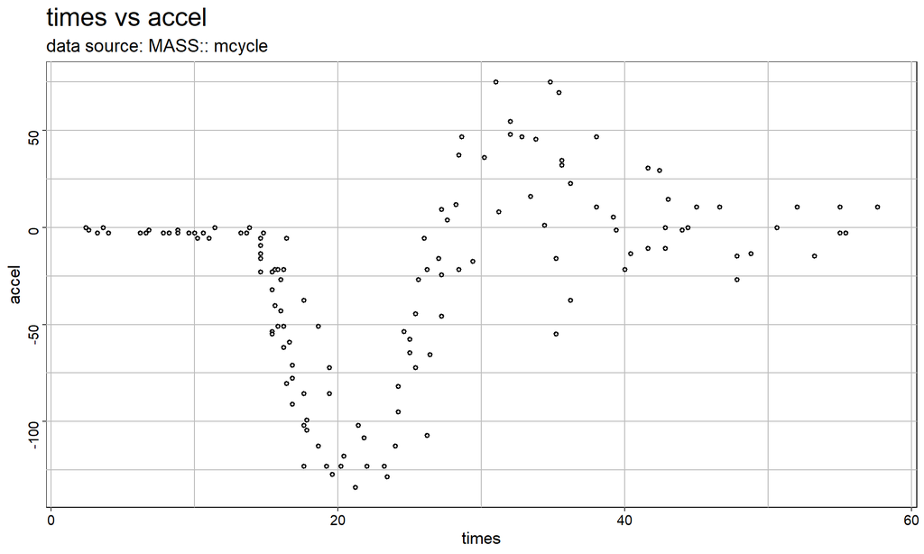

```r
RplotterPkg::create_scatter_plot(
  df = mcycle,
  aes_x = "times",
  aes_y = "accel",
  title = "times vs accel",
  subtitle = "data source: MASS:: mcycle"
)
```

Task: Fit a linear model to *mcycle*.

```r
mcycle_lm <- stats::lm(formula = accel ~ times, data = mcycle)
summary(mcycle_lm)
```

```
##
## Call:
## stats::lm(formula = accel ~ times, data = mcycle)
##
## Residuals:
##      Min       1Q   Median       3Q      Max
## -104.114  -25.926    4.582   36.163   94.197
##
## Coefficients:
##             Estimate Std. Error t value Pr(>|t|)
## (Intercept)  -53.008      8.713  -6.084  1.2e-08 ***
## times          1.091      0.307   3.552 0.000532 ***
## ---
## Signif. codes:  0 '***' 0.001 '**' 0.01 '*' 0.05 '.' 0.1 ' ' 1
##
## Residual standard error: 46.33 on 131 degrees of freedom
## Multiple R-squared:  0.08785,    Adjusted R-squared:  0.08089
## F-statistic: 12.62 on 1 and 131 DF,  p-value: 0.0005318
```

Task: Plot the linear model over the observed data.

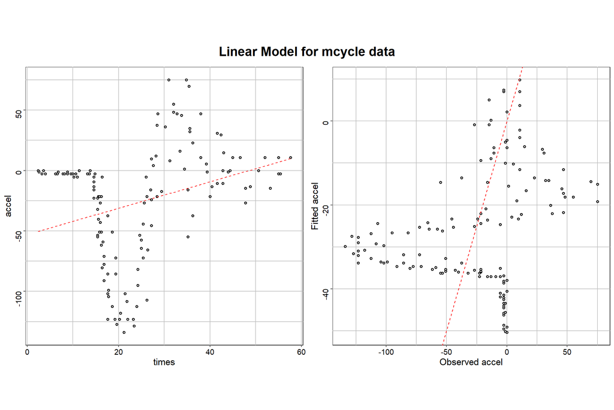

```r
mcycle_lm_plot <- RregressPkg::plot_xy_fit(
  x = mcycle$times,
  y = mcycle$accel,
  fit = mcycle_lm$fitted.values,
  title = "Linear Model for mcycle data",
  x_title = "times",
  y_title = "accel",
  fit_color = "red",
  col_width = 6,
  row_height = 6
)
```

Note: Not a good fit.

## 1.3 Motorcycle crash data: non-linear approach

Task: Use the `mgcv::` package to fit a non-linear model.

```r
mcycle_mod_gam <- mgcv::gam(formula = accel ~ s(times), data = mcycle)
summary(mcycle_mod_gam)
```

```
##
## Family: gaussian
## Link function: identity
##
## Formula:
## accel ~ s(times)
##
## Parametric coefficients:
##             Estimate Std. Error t value Pr(>|t|)
## (Intercept)  -25.546      1.951   -13.1   <2e-16 ***
## ---
## Signif. codes:  0 '***' 0.001 '**' 0.01 '*' 0.05 '.' 0.1 ' ' 1
##
## Approximate significance of smooth terms:
##            edf Ref.df     F p-value
## s(times) 8.693  8.972 53.52  <2e-16 ***
## ---
## Signif. codes:  0 '***' 0.001 '**' 0.01 '*' 0.05 '.' 0.1 ' ' 1
##
## R-sq.(adj) =  0.783   Deviance explained = 79.8%
## GCV = 545.78  Scale est. = 506       n = 133
```

Task: Plot the GAM model *mcycle_mod_gam* for the `mcycle` data set.

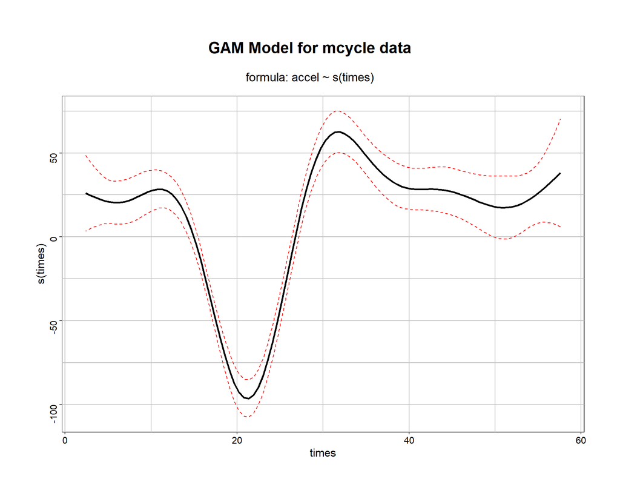

```r
RgamPkg::plot_gam_1d(
  gam_model = mcycle_mod_gam,
  col_width = 9,
  row_height = 6,
  title = "GAM Model for mcycle data",
  subtitle = "formula: accel ~ s(times)"
)
```

Task: Plot the observed data over the GAM fit.

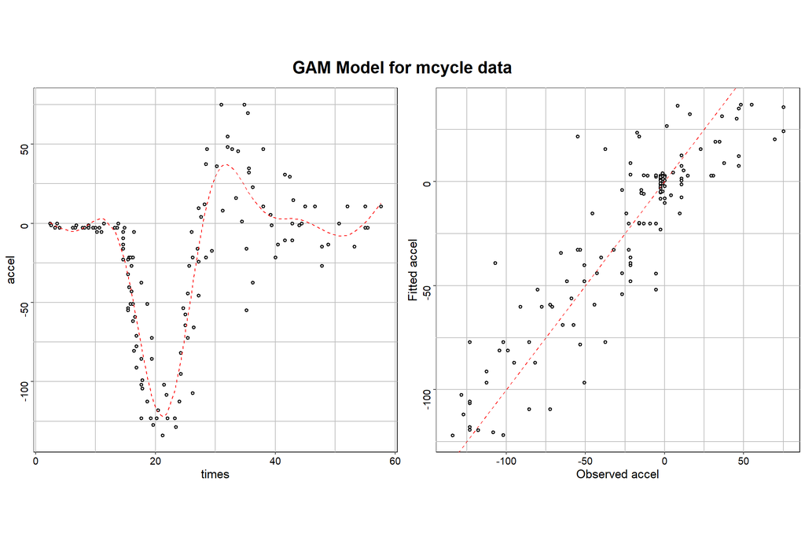

```r
mcycle_gam_fit_plot <- RregressPkg::plot_xy_fit(
  x = mcycle_mod_gam$model$times,
  y = mcycle_mod_gam$model$accel,
  fit = mcycle_mod_gam$fitted.values,
  title = "GAM Model for mcycle data",
  x_title = "times",
  y_title = "accel",
  fit_color = "red",
  col_width = 6,
  row_height = 6
)
```

Note: Better fit from GAM.

## 1.4 Parts of non-linear function

Task: Extract the model coefficients of the *mcycle_mod_gam* model.

```r
mcycle_coef_gam <- stats::coef(mcycle_mod_gam)
(mcycle_coef_gam)
```

```
## (Intercept)  s(times).1  s(times).2  s(times).3  s(times).4  s(times).5
##  -25.545865  -63.718008   43.475644 -110.350132  -22.181006   35.034423
##  s(times).6  s(times).7  s(times).8  s(times).9
##   93.176458   -9.283018 -111.661472   17.603782
```

Task: Plot the GAM model using `mgcv::plot.gam()` function.

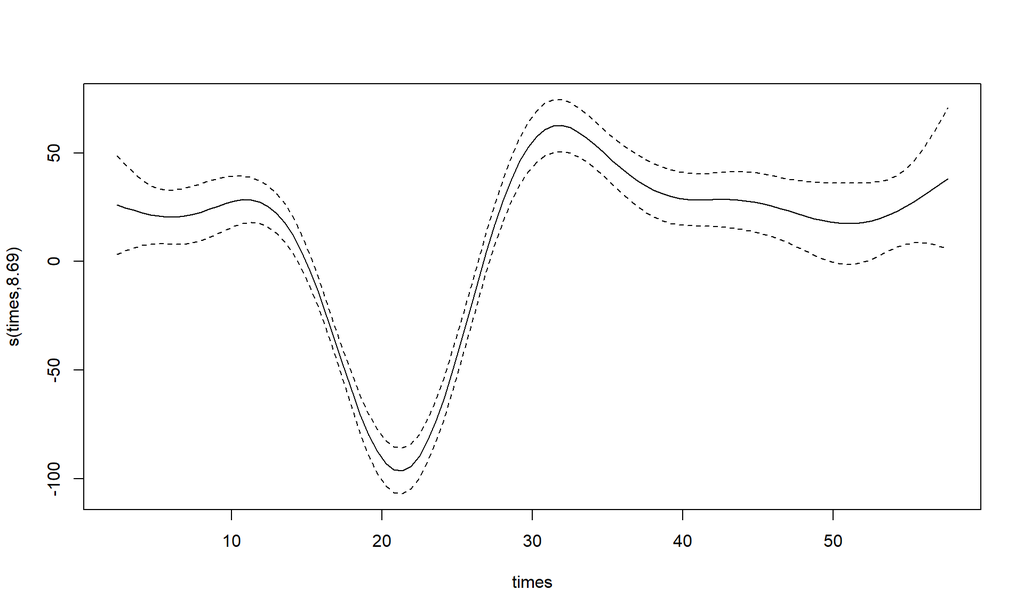

```r
mgcv::plot.gam(mcycle_mod_gam, rug = FALSE)
```

Task: Plot the GAM basis spline functions along with the resulting fitted line and observation points.

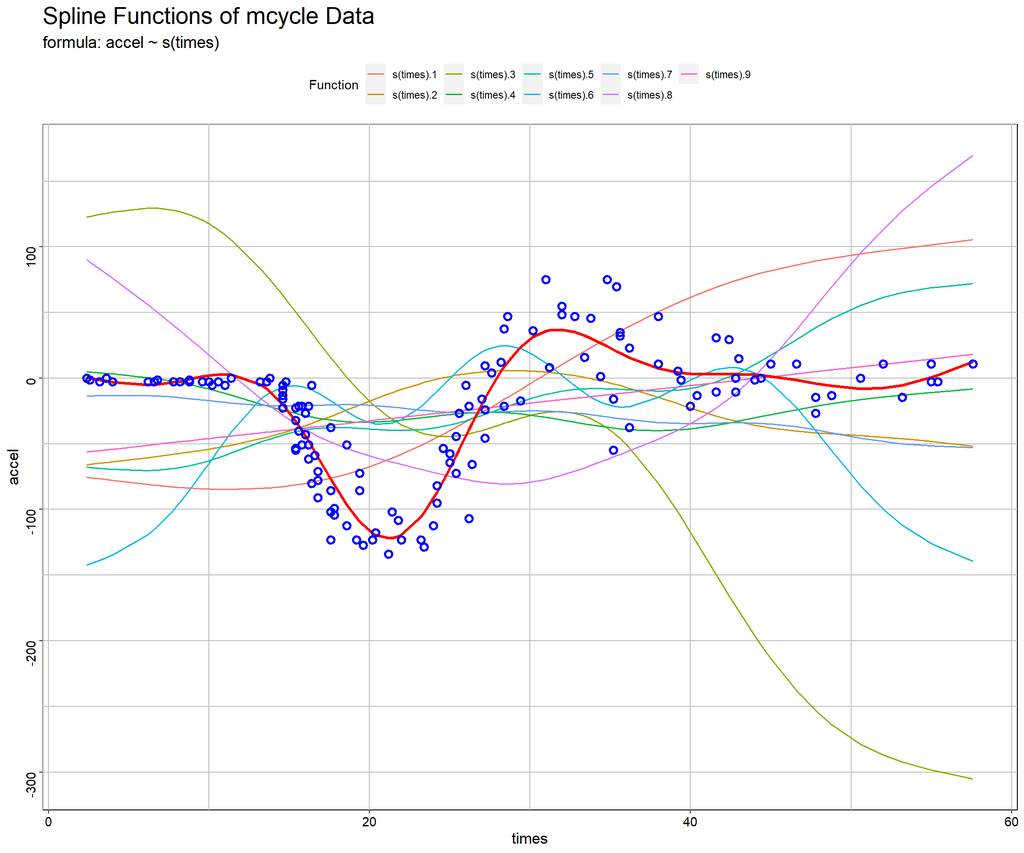

```r
RgamPkg::plot_basis_splines_1d(
  gam_model = mcycle_mod_gam,
  data_var = "times",
  show_points = TRUE,
  title = "Spline Functions of mcycle Data",
  subtitle = "formula: accel ~ s(times) ",
  line_type = "solid"
)
```

## 1.6 Setting complexity of the motorcycle model

Task: Fit and plot a GAM with 3 basis functions for the *mcycle* data.

1. Create the model:

```r
mcycle_mod_k3_gam <- mgcv::gam(accel ~ s(times, k = 3), data = mcycle)
```

2. Plot the GAM model:

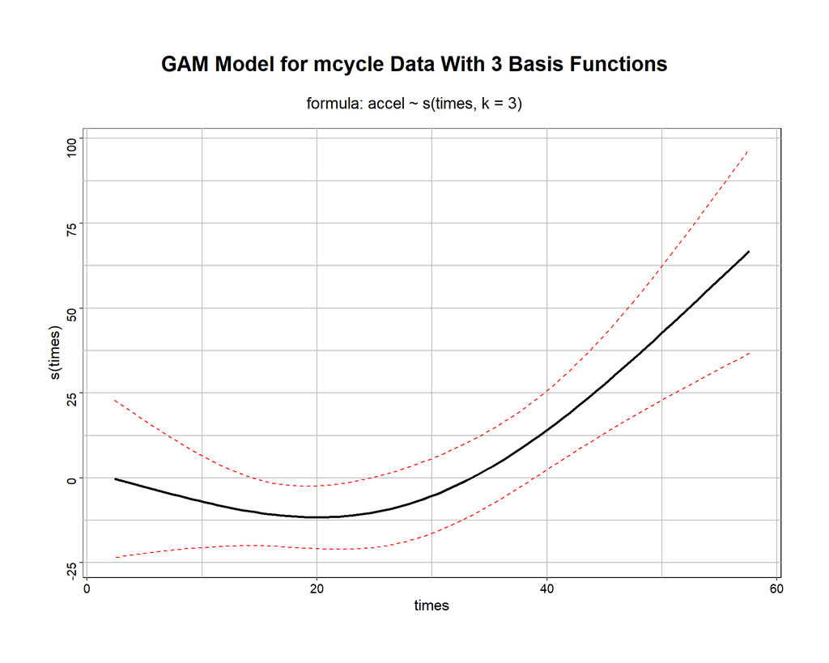

```r
RgamPkg::plot_gam_1d(
  gam_model = mcycle_mod_k3_gam,
  col_width = 9,
  row_height = 6,
  title = "GAM Model for mcycle Data With 3 Basis Functions",
  subtitle = "formula: accel ~ s(times, k = 3)"
)
```

3. Plot the fit:

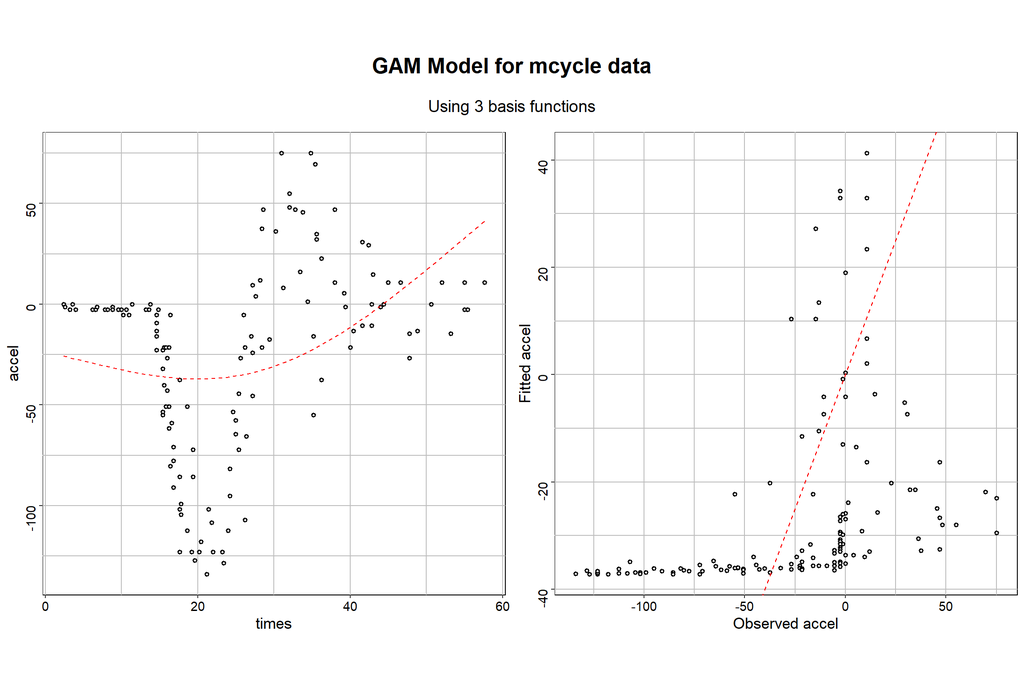

```r
mcycle_gam_fit_k3_plot <- RregressPkg::plot_xy_fit(
  x = mcycle$times,
  y = mcycle$accel,
  fit = mcycle_mod_k3_gam$fitted.values,
  title = "GAM Model for mcycle data",
  subtitle = "Using 3 basis functions",
  x_title = "times",
  y_title = "accel",
  fit_color = "red",
  col_width = 6,
  row_height = 6
)
```

Task: Fit and plot a GAM with 20 basis functions for the *mcycle* data.

1. Create the model:

```r
mcycle_mod_k20_gam <- mgcv::gam(accel ~ s(times, k = 20), data = mcycle)
```

2. Plot the GAM model:

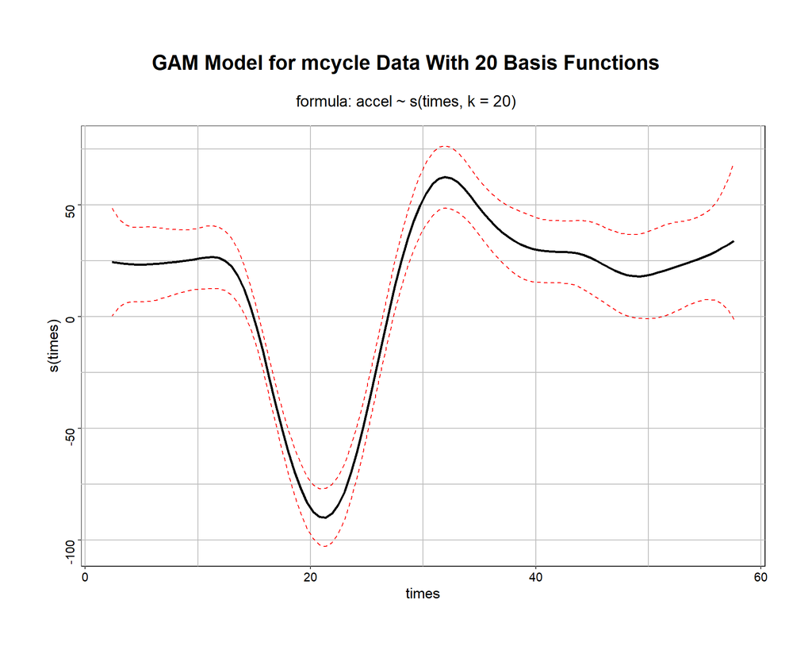

```r
RgamPkg::plot_gam_1d(
  gam_model = mcycle_mod_k20_gam,
  col_width = 9,
  row_height = 6,
  title = "GAM Model for mcycle Data With 20 Basis Functions",
  subtitle = "formula: accel ~ s(times, k = 20)"
)
```

3. Plot the fit:

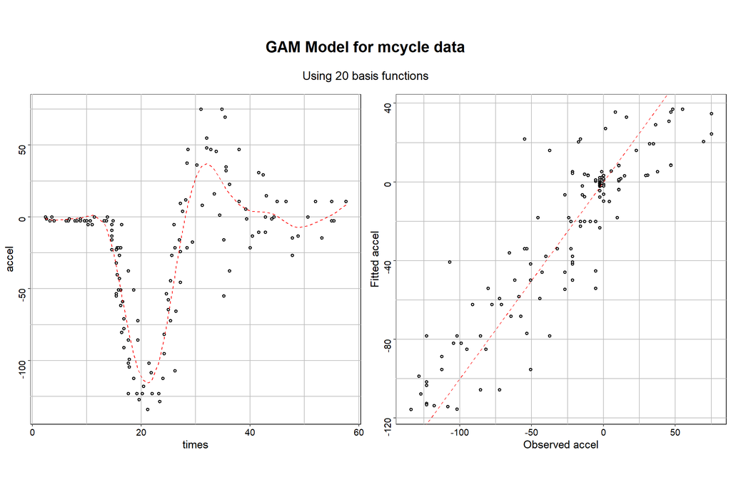

```r
mcycle_gam_fit_k20_plot <- RregressPkg::plot_xy_fit(
  x = mcycle$times,
  y = mcycle$accel,
  fit = mcycle_mod_k20_gam$fitted.values,
  title = "GAM Model for mcycle data",
  subtitle = "Using 20 basis functions",
  x_title = "times",
  y_title = "accel",
  fit_color = "red",
  col_width = 6,
  row_height = 6
)
```

## 1.7 Using smoothing parameters to avoid overfitting

Task: Extract the smoothing parameter $\lambda$ from the above GAM model *mcycle_mod_gam*.

```r
(mcycle_mod_gam$sp)
```

```
##     s(times)
## 0.0006195886
```

Task: Fix the smoothing parameter $\lambda$ to 0.1 and plot.

1. Create the model:

```r
mcycle_mod_.1_gam <- mgcv::gam(formula = accel ~ s(times), data = mcycle, sp = 0.1)
```

2. Plot the GAM model:

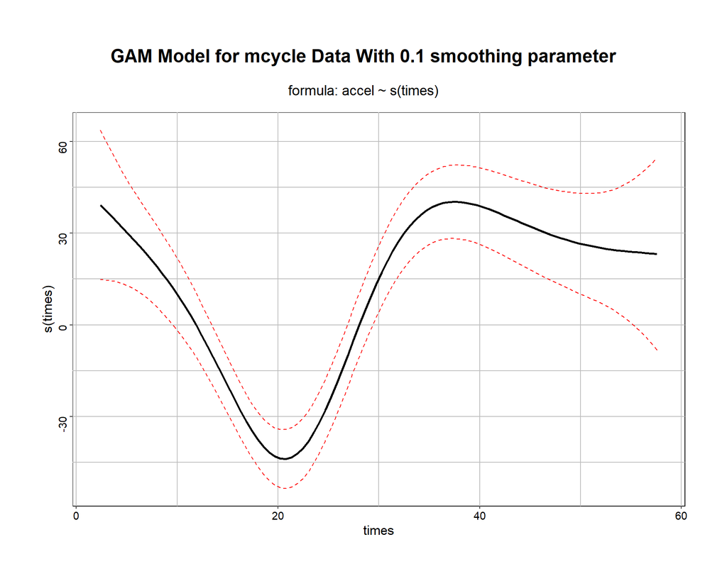

```r
RgamPkg::plot_gam_1d(
  gam_model = mcycle_mod_.1_gam,
  col_width = 9,
  row_height = 6,
  title = "GAM Model for mcycle Data With 0.1 smoothing parameter",
  subtitle = "formula: accel ~ s(times)"
)
```

3. Plot the fit:

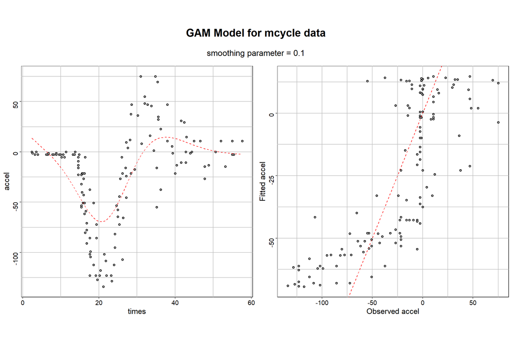

```r
mcycle_gam_fit_plot <- RregressPkg::plot_xy_fit(
  x = mcycle$times,
  y = mcycle$accel,
  fit = mcycle_mod_.1_gam$fitted.values,
  title = "GAM Model for mcycle data",
  subtitle = "smoothing parameter = 0.1",
  x_title = "times",
  y_title = "accel",
  fit_color = "red",
  col_width = 6,
  row_height = 6
)
```

Note: GAM at 0.1 is missing the dip.

## 1.8 Complexity and smoothing together

Task: Plot an over fitting with 50 basis functions and smoothing parameter of 0.0001

1. Create the model:

```r
mcycle_mod_k50_gam <- mgcv::gam(formula = accel ~ s(times,k = 50), data = mcycle, sp = 0.0001)
```

2. Plot the GAM model:

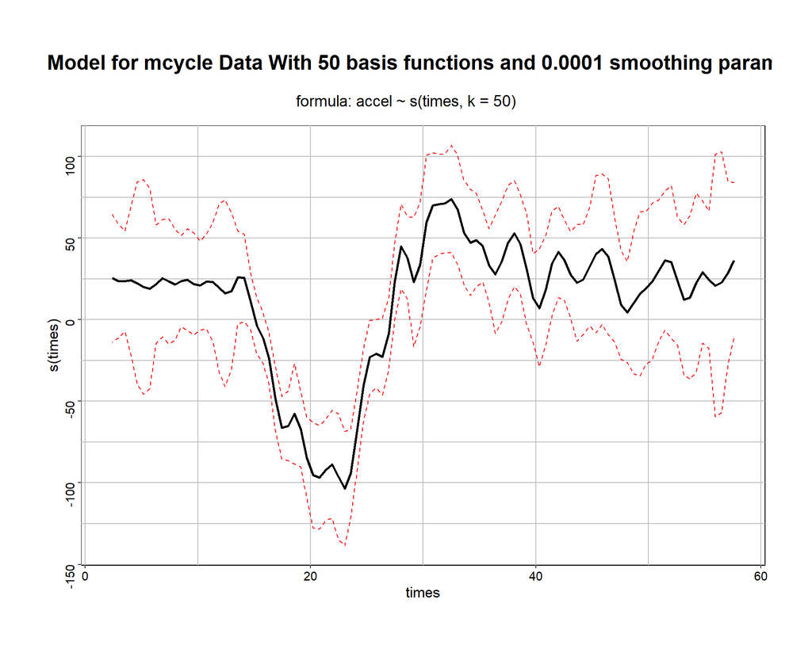

```r
RgamPkg::plot_gam_1d(
  gam_model = mcycle_mod_k50_gam,
  col_width = 9,
  row_height = 6,
  title = "GAM Model for mcycle Data With 50 basis functions and 0.0001 smoothing parameter",
  subtitle = "formula: accel ~ s(times, k = 50)"
)
```

3. Plot the fit:

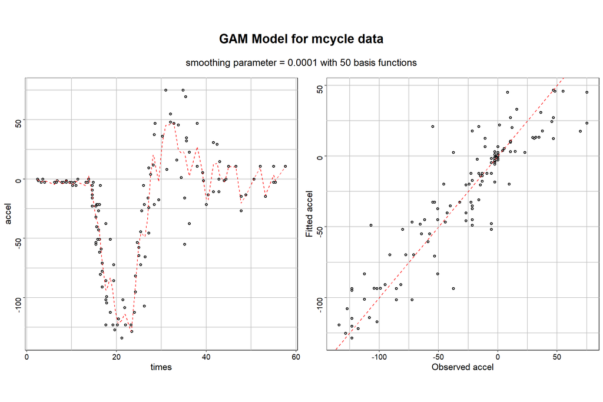

```r
mcycle_gam_fit_k50_plot <- RregressPkg::plot_xy_fit(
  x = mcycle$times,
  y = mcycle$accel,
  fit = mcycle_mod_k50_gam$fitted.values,
  title = "GAM Model for mcycle data",
  subtitle = "smoothing parameter = 0.0001 with 50 basis functions",
  x_title = "times",
  y_title = "accel",
  fit_color = "red",
  col_width = 6,
  row_height = 6
)
```

Note: Appears to be an over fitted.

# 1.9 Multivariate GAMs

Using the *gamair::mpg* data set:

```r
data(mpg)
str(mpg)
```

```
## 'data.frame':    205 obs. of  26 variables:
##  $ symbol    : int  3 3 1 2 2 2 1 1 1 0 ...
##  $ loss      : int  NA NA NA 164 164 NA 158 NA 158 NA ...
##  $ make      : Factor w/ 22 levels "alfa-romero",..: 1 1 1 2 2 2 2 2 2 2 ...
##  $ fuel      : Factor w/ 2 levels "diesel","gas": 2 2 2 2 2 2 2 2 2 2 ...
##  $ aspir     : Factor w/ 2 levels "std","turbo": 1 1 1 1 1 1 1 1 2 2 ...
##  $ doors     : Factor w/ 2 levels "four","two": 2 2 2 1 1 2 1 1 1 2 ...
##  $ style     : Factor w/ 5 levels "convertible",..: 1 1 3 4 4 4 4 5 4 3 ...
##  $ drive     : Factor w/ 3 levels "4wd","fwd","rwd": 3 3 3 2 1 2 2 2 2 1 ...
##  $ eng.loc   : Factor w/ 2 levels "front","rear": 1 1 1 1 1 1 1 1 1 1 ...
##  $ wb        : num  88.6 88.6 94.5 99.8 99.4 ...
##  $ length    : num  169 169 171 177 177 ...
##  $ width     : num  64.1 64.1 65.5 66.2 66.4 66.3 71.4 71.4 71.4 67.9 ...
##  $ height    : num  48.8 48.8 52.4 54.3 54.3 53.1 55.7 55.7 55.9 52 ...
##  $ weight    : int  2548 2548 2823 2337 2824 2507 2844 2954 3086 3053 ...
##  $ eng.type  : Factor w/ 7 levels "dohc","dohcv",..: 1 1 6 4 4 4 4 4 4 4 ...
##  $ cylinders : Factor w/ 7 levels "eight","five",..: 3 3 4 3 2 2 2 2 2 2 ...
##  $ eng.cc    : int  130 130 152 109 136 136 136 136 131 131 ...
##  $ fuel.sys  : Factor w/ 8 levels "1bbl","2bbl",..: 6 6 6 6 6 6 6 6 6 6 ...
##  $ bore      : num  3.47 3.47 2.68 3.19 3.19 3.19 3.19 3.19 3.13 3.13 ...
##  $ stroke    : num  2.68 2.68 3.47 3.4 3.4 3.4 3.4 3.4 3.4 3.4 ...
##  $ comp.ratio: num  9 9 9 10 8 8.5 8.5 8.5 8.3 7 ...
##  $ hp        : int  111 111 154 102 115 110 110 110 140 160 ...
##  $ rpm       : int  5000 5000 5000 5500 5500 5500 5500 5500 5500 5500 ...
##  $ city.mpg  : int  21 21 19 24 18 19 19 19 17 16 ...
##  $ hw.mpg    : int  27 27 26 30 22 25 25 25 20 22 ...
##  $ price     : int  13495 16500 16500 13950 17450 15250 17710 18920 23875 NA ...
```

Task: From the *mpg* data set create a GAM model of *hw.mpg* dependent on *weight* and plot.

1. Create the model:

```r
hw_weight_gam <- mgcv::gam(hw.mpg ~ s(weight), data = mpg, method = "REML")
summary(hw_weight_gam)
```

```
##
## Family: gaussian
## Link function: identity
##
## Formula:
## hw.mpg ~ s(weight)
##
## Parametric coefficients:
##             Estimate Std. Error t value Pr(>|t|)
## (Intercept)   30.751      0.268   114.7   <2e-16 ***
## ---
## Signif. codes:  0 '***' 0.001 '**' 0.01 '*' 0.05 '.' 0.1 ' ' 1
##
## Approximate significance of smooth terms:
##             edf Ref.df     F p-value
## s(weight) 4.288  5.343 84.96  <2e-16 ***
## ---
## Signif. codes:  0 '***' 0.001 '**' 0.01 '*' 0.05 '.' 0.1 ' ' 1
##
## R-sq.(adj) =  0.689   Deviance explained = 69.6%
## -REML = 570.04  Scale est. = 14.725    n = 205
```

2. Plot the fit:

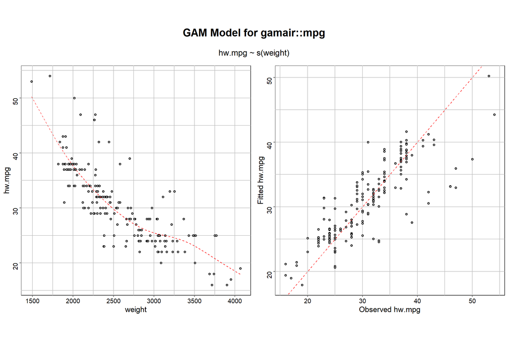

```r
hw_weight_gam_plot <- RregressPkg::plot_xy_fit(
  x = hw_weight_gam$model$weight,
  y = hw_weight_gam$model$hw.mpg,
  fit = hw_weight_gam$fitted.values,
  title = "GAM Model for gamair::mpg",
  subtitle = "hw.mpg ~ s(weight)",
  x_title = "weight",
  y_title = "hw.mpg",
  fit_color = "red",
  col_width = 6,
  row_height = 6
)
```

Task: From the *mpg* data set create a GAM model of *hw.mpg* dependent on *weight*, *length* and plot.

1. Create the model:

```r
hw_weight_length_gam <- mgcv::gam(hw.mpg ~ s(weight) + s(length), data = mpg, method = "REML")
summary(hw_weight_length_gam)
```

```
##
## Family: gaussian
## Link function: identity
##
## Formula:
## hw.mpg ~ s(weight) + s(length)
##
## Parametric coefficients:
##             Estimate Std. Error t value Pr(>|t|)
## (Intercept)  30.7512     0.2619   117.4   <2e-16 ***
## ---
## Signif. codes:  0 '***' 0.001 '**' 0.01 '*' 0.05 '.' 0.1 ' ' 1
##
## Approximate significance of smooth terms:
##             edf Ref.df      F p-value
## s(weight) 4.577  5.672 24.895  <2e-16 ***
## s(length) 3.143  4.001  2.261  0.0638 .
## ---
## Signif. codes:  0 '***' 0.001 '**' 0.01 '*' 0.05 '.' 0.1 ' ' 1
##
## R-sq.(adj) =  0.703   Deviance explained = 71.5%
## -REML = 567.02  Scale est. = 14.064    n = 205
```

2. Plot the GAM model:

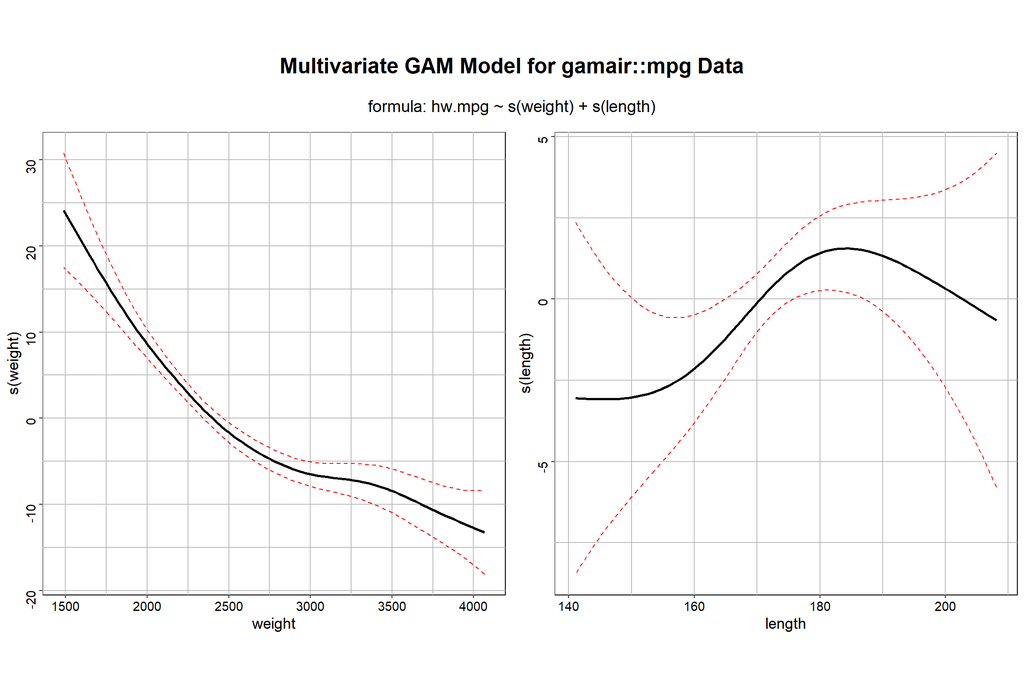

```r
RgamPkg::plot_gam_1d(
  gam_model = hw_weight_length_gam,
  col_width = 6,
  row_height = 6,
  title = "Multivariate GAM Model for gamair::mpg Data",
  subtitle = "formula: hw.mpg ~ s(weight) + s(length)"
)
```

3. Plot the fit:

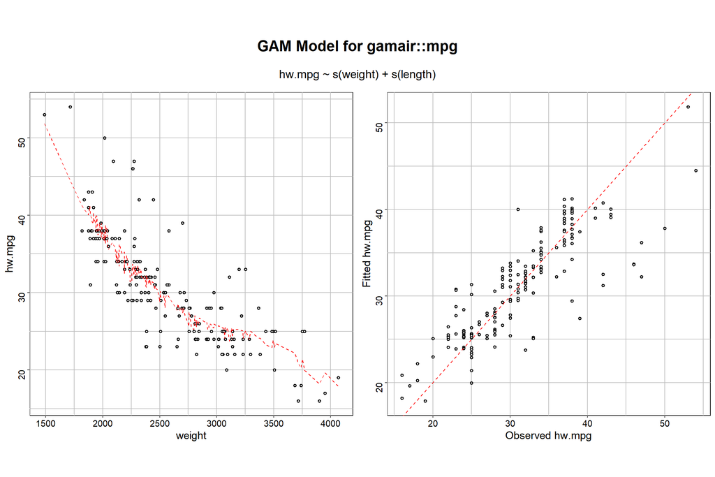

```r
hw_weight_length_gam_plot <- RregressPkg::plot_xy_fit(
  x = hw_weight_length_gam$model$weight,
  y = hw_weight_length_gam$model$hw.mpg,
  fit = hw_weight_length_gam$fitted.values,
  title = "GAM Model for gamair::mpg",
  subtitle = "hw.mpg ~ s(weight) + s(length)",
  x_title = "weight",
  y_title = "hw.mpg",
  fit_color = "red",
  col_width = 6,
  row_height = 6
)
```